# Projeto: Vacinas Salvam Vidas

## Uma análise da eficâcia do Programa Nacional de Imunizações (PNI) e uma breve solução para o negacionismo do movimento antivacina

[figure not shown]

## 🎯 Objetivo do projeto

O principal objetivo desse projeto é fazer uma análise da eficâcia do Programa Nacional de Imunizações (PNI) mostrando que vacinas podem sim reduzir o número de mortes relacionadas à determinadas doenças.

## ⭐ Introdução

### 🚫 O movimento antivacina

Segundo um relatório da OMS, divulgado em 2019, o movimento antivacina é considerado um dos maiores problemas a saúde global. Esse movimento vai contra todo o avançado cientifico alcançado no combate as doenças letais que podem ser evitadas, ou reduzidas, com o Programa de Imunização Nacional.

[figure not shown]

foto por: AMANDA PEROBELLI / REUTERS

Muitas são as razões que uma pessoa pode ter para não se vacinar ou para não levarem seus filhos para a vacinação, um desses motivos é a falta ou dificuldade de acesso, em determinadas regiões sociogeográficas. Entretando, a falta de confiança nas vacinas vem crescendo devido esse movimento negacionista, que por muitas das vezes diz que ou a vacina não funciona, ou é uma forma do governo eliminar determinados grupos sociais ou até mesmo alegando que o governo irá implantar uma espécie de "chip" que irá controlar ou rastear essas pessoas, afirmações que chegam a ser ridiculas dado todo o avanço e beneficio que iremos discutir ao longo do desenvolvimento desse projeto.

### 👍 Por que o SUS é importante?

O SUS (Sistema Único de Saúde) dá o direito à saúde para qualquer cidadão brasileiro, oferecendo acesso integral, universal e gratuito a serviços de saúde.

Paralelamente à realização de consultas, exames e internações, o SUS também promove campanhas de vacinação e ações de prevenção de vigilância sanitária, como fiscalização de alimentos e registro de medicamentos.

[figure not shown]

E apesar de alguns problemas nas questões de distribuição de verba pública pelo governo, o SUS é responsável por disponibilizar, gerenciar e distribuir diversas doses de vacinas anualmente para população alvo de forma completamente gratuita.

#### Programa Nacional de Imunizações (PNI)

O Programa Nacional de Imunizações (PNI) é uma ação do Governo Federal e que tem por objetivo eliminar, por meio da vacinação em massa da população, uma série de doenças. Como resultado, entre os casos de sucesso estão a erradicação da varíola e da poliomielite do territorio nacional.

Por meio desse programa, toda a população brasileira tem acesso às vacinas recomendadas pela Organização Mundial de Saúde (OMS).

O PNI tem como objetivos a inclusão social, ao permitir que qualquer cidadão tenha acesso às imunizações.

### 🎲 Dados públicos

Dados públicos são dados que estão disponíveis para qualquer pessoa acessar, esses dados não tem nenhum tipo de controle ou privação de acesso. São dados públicos, geralmente dados que toda população deve ou pode ter acesso, como por exemplo, dados que indicam os gastos de parlamentares com o dinheiro público (dinheiro que provem de impostos de forma direta ou indireta).

#### Tabnet e o DataSUS

"O aplicativo TABNET é um tabulador genérico de domínio público que permite organizar dados de forma rápida conforme a consulta que se deseja tabular. Foi desenvolvido pelo DATASUS para gerar informações das bases de dados do Sistema Único de Saúde." <sub><sup>[http://www2.datasus.gov.br/DATASUS/APRESENTACAO/TABNET/Tutorial_tabNet_FINAL.pptx_html/html/index.html#2](http://www2.datasus.gov.br/DATASUS/APRESENTACAO/TABNET/Tutorial_tabNet_FINAL.pptx_html/html/index.html#2)</sup></sub>

"O DATASUS disponibiliza informações que podem servir para subsidiar análises objetivas da situação sanitária, tomadas de decisão baseadas em evidências e elaboração de programas de ações de saúde.

A mensuração do estado de saúde da população é uma tradição em saúde pública. Teve seu início com o registro sistemático de dados de mortalidade e de sobrevivência (Estatísticas Vitais - Mortalidade e Nascidos Vivos). Com os avanços no controle das doenças infecciosas (informações Epidemiológicas e Morbidade) e com a melhor compreensão do conceito de saúde e de seus determinantes populacionais, a análise da situação sanitária passou a incorporar outras dimensões do estado de saúde.

Dados de morbidade, incapacidade, acesso a serviços, qualidade da atenção, condições de vida e fatores ambientais passaram a ser métricas utilizadas na construção de Indicadores de Saúde, que se traduzem em informação relevante para a quantificação e a avaliação das informações em saúde." <sub><sup>[http://www2.datasus.gov.br/DATASUS/index.php?area=02](http://www2.datasus.gov.br/DATASUS/index.php?area=02)</sup></sub>

## 📚 Importação de bibliotecas

Nessa seção é feita a importação de todas bibliotecas utilizadas no decorrer do projeto.

```python
import pandas as pd
import seaborn as sns
import datetime
import matplotlib.pyplot as plt
import matplotlib.ticker as ticker
from functions import loading_tabela_cobertura_imunobiologicos
from functions import all_data_processing
from functions import grafico_cobertura_vacinais_casos_confirmados_por_estado
from functions import grafico_cobertura_vacinais_casos_confirmados_por_regiao
from functions import grafico_cobertura_vacinais_casos_confirmados_por_regiao_por_ano
from functions import grafico_cobertura_vacinais_casos_confirmados_macro_regiao
```

## 📝 Nota técnica e Origem dos dados

Os dados relacionados a cobertura vacinal nesse projeto, são oriundos do [Sistema de Avaliação do Programa de Imunizações - API](http://pni.datasus.gov.br/), sistema este gerido pela Coordenação Geral do Programa Nacional de Imunizações - CGPNI, do Departamento de Vigilância Epidemiológica, Secretaria de Vigilância em Saúde, do Ministério da Saúde, em conjunto com as Secretarias Estaduais de Saúde, suas regionais e as Secretarias Municipais de Saúde.

As Secretarias Municipais de Saúde coletam, por meio do Boletim Diário de Doses Aplicadas de Vacinas, os quantitativos de indivíduos vacinados por faixa etária em cada Estabelecimento de Saúde (salas de vacina), consolidando essas informações nos Boletins Mensais, com registro no Sistema API em todas as instâncias.

A base de dados estadual é enviada mensalmente para a CGPNI/DEVEP/SVS/MS, quando então é consolidada a base nacional.  
<sup><sub>Nota técnica completa em: [http://tabnet.datasus.gov.br/cgi/pni/Imun_cobertura_desde_1994.pdf](http://tabnet.datasus.gov.br/cgi/pni/Imun_cobertura_desde_1994.pdf) ou, caso o link chegue a ficar offline futuramente, ficará disponível localmente: [../technical_notes/Imun_cobertura_desde_1994.pdf](../technical_notes/Imun_cobertura_desde_1994.pdf)</sub></sup>

Esses dados foram coletados no [Tabnet do PNI](http://tabnet.datasus.gov.br/cgi/tabcgi.exe?pni/cnv/cpniuf.def), aplicando os seguintes filtros:

- Linha: Ano
- Coluna: Unidade da Federação
- Conteúdo: Coberturas Vacinais
- Período disponíveis: 1994 - 2019

Com isso, foi obitido a seguinte coleção de dados (dataset) em CSV, que se encontra nesse projeto em ../datasets/Cobertura_Vacinais_Ano_Unidade_Federacao_1994_2019.csv

Esses dados coletados são referentes à seguinte tabela de Imunobiológicos com determinada Cobertura:  
<sup><sub>Descrição das variáveis disponíveis para tabulação: [http://tabnet.datasus.gov.br/cgi/pni/%5Ccpnidescr.htm](http://tabnet.datasus.gov.br/cgi/pni/%5Ccpnidescr.htm)</sub></sup>

```python
loading_tabela_cobertura_imunobiologicos()
```

| Imunobiológico | Período (a partir de) | População-alvo | Cobertura com: |
| --- | --- | --- | --- |
| BCG (BCG) | 1994 | < 1 ano | 1ª dose |
| Contra Febre Amarela (FA) | 1994 | < 1 ano | 1ª dose |
| Contra Haemophilus influenzae tipo b (Hib)(a) | 2000 a 2002 | < 1 ano | 3ª dose |
| Contra Hepatite B (HB) | 1994 | < 1 ano | 3ª dose |
| Contra Influenza (campanha) (INF) | 1999 | 65 anos e mais (1999) | Dose única |
| Contra Influenza (campanha) (INF) | 1999 | 60 anos e mais (a partir de 2000) | Dose única |
| Contra Sarampo(b) | 1994 a 2002 | < 1 ano | Dose única |
| Dupla Viral (SR) | 2001 a 2004 | 1 ano(3) | Dose única |
| Oral contra poliomielite (VOP) | 1994 | < 1 ano | 3ª dose |
| Oral Contra Poliomielite (1ª etapa) (VOP) | 1994 | até 1999: < 1 ano | Dose única |
| Oral Contra Poliomielite (1ª etapa) (VOP) | 2000 | de 0 a 4 anos(4) | Dose única |
| Oral Contra Poliomielite (2ª etapa) (VOP) | 1994 | até 1999: < 1 ano | Dose única |
| Oral Contra Poliomielite (2ª etapa) (VOP) | 2000 | de 0 a 4 anos(4) | Dose única |
| Oral de Rotavírus Humano (RR) | 2006 | < 1 ano (6 a 24 semanas de vida) | 2ª dose |
| Tetravalente (DTP/Hib) (TETRA) | 2002 | < 1 ano | 3ª dose |
| Tríplice Viral (SCR) | 2000 | 1 ano | 1ª dose |
| Tríplice Viral (campanha) (SCR) | 2004 | 1 ano(3) | 1ª dose |

Além disso, também vamos utilizar os dados relacionados aos diagnósticos de Tuberculose disponibilizados no [Tabnet do DataSUS de Tuberculose](http://tabnet.datasus.gov.br/cgi/tabcgi.exe?sinannet/cnv/tubercbr.def), aplicando os seguintes filtros:

- Linha: Ano Diagnóstico
- Coluna: UF de notificação
- Conteúdo: Casos confirmados
- Período disponíveis: 2001 - 2019

Com isso, foi obitido a seguinte coleção de dados (dataset) em CSV, que se encontra nesse projeto em ../datasets/Tuberculose_Ano_UF_Confirmados.csv

## 👨‍💻 Carregamento e Processamento dos dados

Vamos fazer todo o carregamento e processamento dos dados utilizando o arquivo functions.py.  
Esse arquivo está separado em seções, sendo elas:

- Seção de funções adicionais para o processamento (mapeamento de dados e inserção de informações)
- Seção para definir funções de carregamento das bases de dados (read_csv e primeira tratativa dos datasets)
- Seção para definir funções de processamento das bases de dados (manipulações dos dados e exclusão de dado lixo)
- Seção para processamento de todos os dados (aplicação da desnormalização, mapeamento e ajustes finais)
- Além disso, temos uma seção para definição de funções para gerar gráficos

Com essas funções definidas, básicamente o que precisa ser feito aqui, é chamar a função "all_data_processing" e salvar os valores dos dataframes para efetuar as plotagem dos gráficos.

```python
df_cobertura_vacinais, df_casos_tuberculose = all_data_processing()
```

Como esses processamentos, temos então que o dataframe "df_cobertura_vacinais", contém as seguintes informações em formato de coluna:

- ano (anos de 1994 até 2019)
- estado (todos estados do Brasil)
- regiao (Região dos estados em relação ao país)
- cobertura (% atingida de cobertura vacinais com base na população alvo)

E o dataframe "df_casos_tuberculose", contém as seguintes informações:

- ano (anos de 2001 até 2019)
- estado (todos estados do Brasil)
- regiao (Região dos estados em relação ao país)
- casos (quantidade de casos confirmados de tuberculose)

## 🤔 Levantamento de Hipóteses

Irei deixar aqui, algumas suposições sobre o que acredito que possa acontecer quando efetuarmos a relação entre Cobertura vacinal e a quantidade absoluta de casos confirmados de tuberculose por estado.

[figure not shown]

⚠️ Deixo aqui também a observação que são só suposições e hipoteses, ou seja, não significa que de fato isso será confirmado ou comprovado, afinal, no mundo real existem diversas variáveis, e analisar a correlação entre Cobertura vacinal e quantidade absoluta de casos confirmados, é apenas uma estimativa que até nos dá uma noção macro do cenário, mas não especifica ou leva em conta outros fatores externos.

- Com o inicio das campanhas de vacinação, provavelmente haverá alguma redução no número absoluto de casos confirmados de tuberculose;
- Caso haja algum tipo de queda na proporção de vacinas aplicadas, o impacto no número absoluto de casos não necessariamente será imediato, visto que o desenvolvimento da doença pode levar um certo período, e temos que levar em conta também em que momento a pessoa foi exposta;
- Em estados maiores(como São Paulo), não necessariamente uma porcentagem alta de cobertura vacinal irá significar uma baixa no número absolutos de casos confirmado, dado que o fluxo de pesoas estrangeiras (seja de outro estado ou país) é maior.

## 📈 Visualização dos dados

Então, com nossas hipóteses definidas, vamos ver alguns gráficos para validar, ou refutar, algumas questões.

Lembrando que, as funções de definições dos gráficos estão no functions.py, na última seção do arquivo.

#### Visão macro do nosso cenário

Para iniciar de fato, eu gosto de ver como está nosso cenário como um todo, por isso, decidi plotar os gráficos de Cobertura vacinais e Casos confirmados de tuberculose de forma ampla, mostrando a tendência média de cada região (com base nos estados).

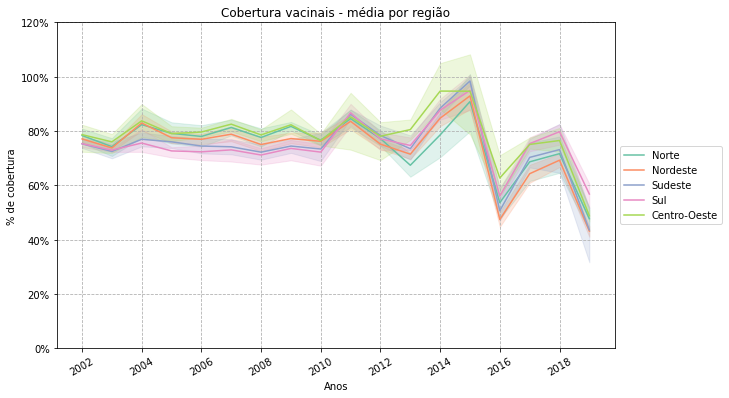

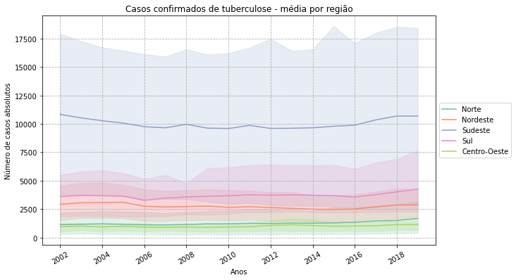

```python
grafico_cobertura_vacinais_casos_confirmados_macro_regiao("Set2", "Set2")
```

Vemos aqui, que a no primeiro gráfico, todas regiões seguem uma mesma tendência de cobertura vacinal, ou seja, em periodos onde uma porcentagem maior da população é vacinada, esse comportamento se repete em todas regiões, e em períodos de queda desse volume, também temos uma questão generalizada (em 2016, por exemplo, teve uma queda das vacinações de modo geral nas regiões).

#### Do macro pro micro: analisando alguns estados por regiões em anos específicos

Agora, para entender melhor o comportamento e a relação das campanhas de vacinações com o número de casos confirmados, vamos analisar algumas regiões especificas, ver estados para se aprofundar e entender se de fato as vacinas tem alguma reação.

##### 1º Estado / Região: Bahia / Nordeste

Como nossas analises estão começando perto do ano de 2002, vamos plotar um gráfico na região nordeste nesse ano para tentar encontrar alguns padrões ou pontos fora da curva.

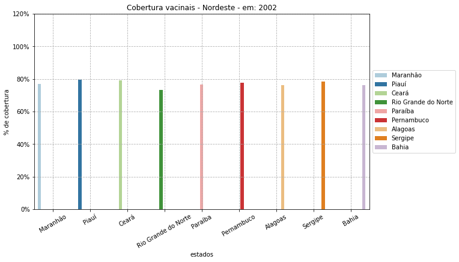

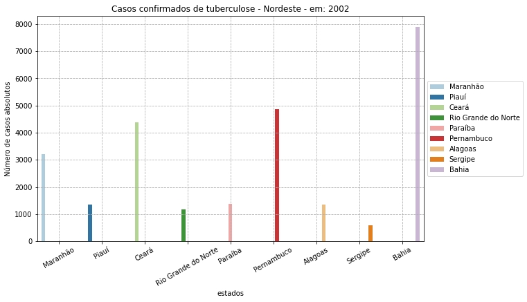

```python
grafico_cobertura_vacinais_casos_confirmados_por_regiao_por_ano("Nordeste", "Paired", "Paired", 2002)
```

Vendo esses gráficos, conseguimos tirar algumas conclusões referente ao ano de 2002 na região Nordeste:

- A distribuição das vacinas em todos os estados dessa região se mostrou bem similar nesse ano em questão;
- Mais da metade dos estados tiveram poucos casos absolutos confirmados, porém Bahia teve quase 8 vezes mais casos confirmados em relação a alguns dos estados. Obviamente isso deve ter alguma relação com a densidade populacional.

Com esses pontos definidos, vamos analisar isoladamente o estado de Bahia para entender se essa alta nos casos de tuberculose, se mantém ou não no decorrer dos anos.

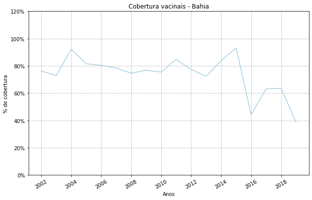

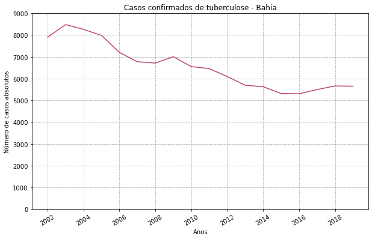

```python
grafico_cobertura_vacinais_casos_confirmados_por_estado("Bahia", "Paired", "flare", 9000)
```

Podemos verificar então que, apesar de ter um começo super alto do número de casos absolutos de tuberculose na Bahia, com o passar dos anos, e com a campanha se mantendo perto dos 80% de cobertura vacinal, verificamos uma ótima queda no número de casos confirmados. Entretanto, se verificarmos no período de 2014, 2015 e 2016, houve uma queda na cobertura vacinal e em 2016 para 2018 refletiu em um leve aumento no número de casos absolutos.

Assim como na primeira região analisada, vamos verificar aqui alguns padrões ou pontos a serem analisados.

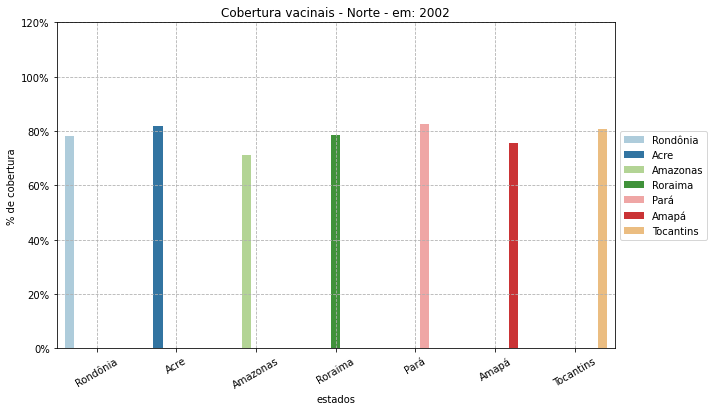

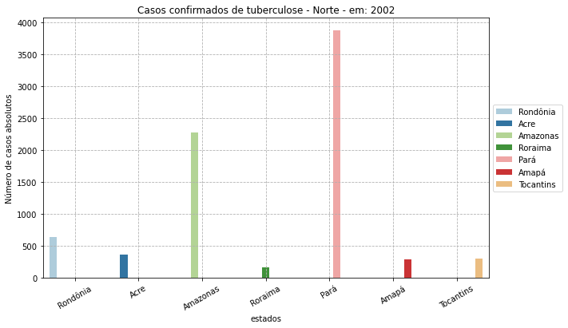

```python
grafico_cobertura_vacinais_casos_confirmados_por_regiao_por_ano("Norte", "Paired", "Paired", 2002)
```

Da mesma forma, conseguimos tirar algumas conclusões da região Norte em 2002:

- Temos uma cobertura vacinal bem similar em todos os estados
- Vemos que o estado do Pará tem um volume alto de casos absolutos confirmados de tuberculose, em relação aos outros estados. Mas isso, pode ser um fenômeno devido a relação do volume populacional.

De qualquer forma, vamos analisar o estado do Pará separadamente para entender alguns pontos.

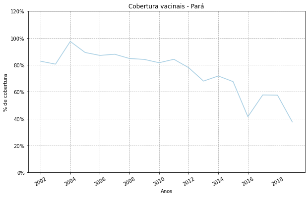

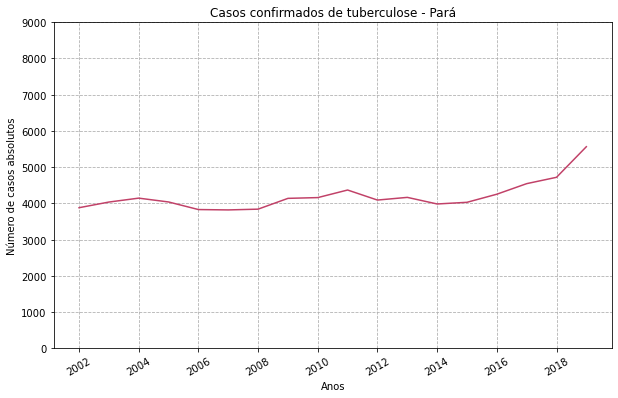

```python
grafico_cobertura_vacinais_casos_confirmados_por_estado("Pará", "Paired", "flare", 9000)
```

#### 3º Estado / Região: São Paulo / Sudeste

E nossa terceira e última região a ser analisada é o Sudeste. Resolvi deixar essa região por fim na nossa análise, devido ao maior volume populacional e também devido ao fluxo maior de pessoas externas (pessoas de outros estados e países que entram e saem do estado por meio de aeroportos e rodoviárias), dado que é a região com o maior polo comercial do país.

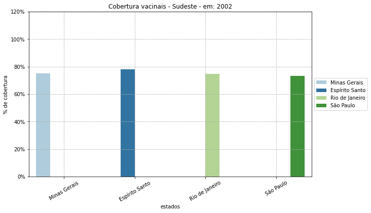

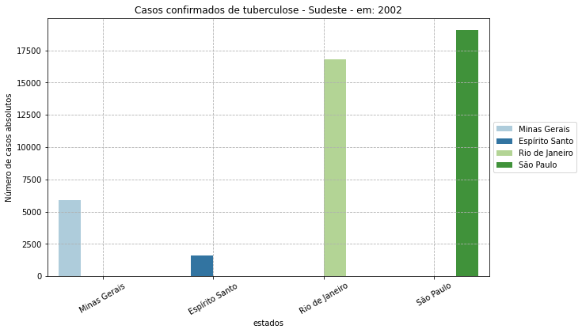

```python
grafico_cobertura_vacinais_casos_confirmados_por_regiao_por_ano("Sudeste", "Paired", "Paired", 2002)
```

- Aqui também temos uma cobertura vacinal bem semelhante entre os estados;
- Porém em São Paulo, como já era de se esperar, temos o maior número de casos absolutos de tuberculose, novamente, por causa do volume populacional, maior fluxo de pessoas e questões ambientais, como a poluição.

Agora, assim como nas outras regiões, vamos isolar o estado com maior número de casos absolutos para verificar o seu comportamento no decorrer dos anos.

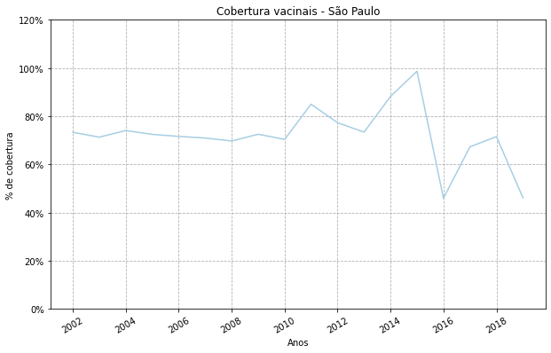

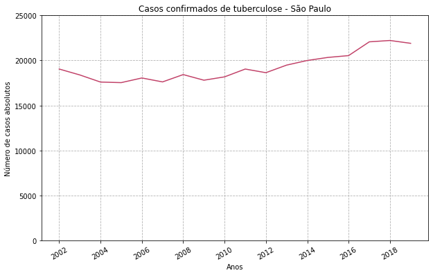

```python
grafico_cobertura_vacinais_casos_confirmados_por_estado("São Paulo", "Paired", "flare", 25000)
```

## 🔗 Referências

##### Informações gerais:

DATASUS: [http://www2.datasus.gov.br/DATASUS/index.php?area=02](http://www2.datasus.gov.br/DATASUS/index.php?area=02)

Sistema de Informações do PNI: [http://pni.datasus.gov.br/](http://pni.datasus.gov.br/)

Imunizações Cobertura – desde 1994 - Notas Técnicas: <http://tabnet.datasus.gov.br/cgi/pni/Imun_cobertura_desde_1994.pdf e http://tabnet.datasus.gov.br/cgi/pni/%5Ccpnidescr.htm>

Tutorial TABNET: [http://www2.datasus.gov.br/DATASUS/APRESENTACAO/TABNET/Tutorial_tabNet_FINAL.pptx_html/html/index.html#2](http://www2.datasus.gov.br/DATASUS/APRESENTACAO/TABNET/Tutorial_tabNet_FINAL.pptx_html/html/index.html#2)

##### Origem dos dados:

TABNET Imunizações: [http://tabnet.datasus.gov.br/cgi/tabcgi.exe?pni/cnv/cpniuf.def](http://tabnet.datasus.gov.br/cgi/tabcgi.exe?pni/cnv/cpniuf.def)

TABNET Tuberculose: [http://tabnet.datasus.gov.br/cgi/tabcgi.exe?sinannet/cnv/tubercbr.def](http://tabnet.datasus.gov.br/cgi/tabcgi.exe?sinannet/cnv/tubercbr.def)